# Lecture 10: PCA - Principle Component Analysis

Zhaoxia Yu

Professor, Department of Statistics

2026-05-31

```r
knitr::opts_chunk$set(echo = TRUE)
library(tidyr) #the pipe (%>%) tool is extremely useful
library(MASS)
library(tidyverse)
```

# Introduction

## PCA: An Overview

- A **component** refers to a **linear** function of features/variables
- The first **principal** component refers to the linear function of the highest “rank/importance”
- The second principal component refers to the linear function of the second highest “rank/importance”
- The principal components in PCA are **uncorrelated** **linear** combinations/functions of features

## Origins of PCA

- 1901: Karl Pearson (Geometric Foundation)
  - First introduced PCA as a method to find the “lines and planes of closest fit” for high-dimensional data.
  - Defined it as a **geometrical** technique to identify directions that maximize **variance**.
- 1933: Harold Hotelling (Statistical Formalization)
  - First used the term “Principal Components” (PC), established statistical and mathematical foundation.
  - Linked PCA to **spectral decomposition**.

## Modern PCA

- PCA has had a significant impact on the field of multivariate analysis and dimensionality reduction.
- Over time, PCA has become a widely used method in various disciplines, such as statistics, data science, finance, and engineering.
- PCA has been extended and generalized, giving rise to many useful dimension reduction techniques like Kernel PCA, sparse PCA, t-SNE, and UMAP.
- sparse PCA: use sparsity constraints on the principal components.
  - Sparse PCA results in more interpretable components that involve only a subset of the original features.
- kernel PCA: captures non-linear relationships between features.
  - PCA can be considered as a special case of kernel PCA with a linear kernel.

### **t-SNE (Global All-Pairs)**

- **Focus:** Strict **local structure** (clusters).
- **Similarity ($q_{ij}$):** Uses **all pairs** for normalization ($O(N^2)$).
  $$q_{ij} = \frac{(1 + ||y_i - y_j||^2)^{-1}}{\sum_{k \neq l} (1 + ||y_k - y_l||^2)^{-1}}$$
- **Complexity:** $O(N^2)$ due to the large denominator sum over **all data points.**
- **Insight:** Excellent at cluster separation; ignores global distances.

## A Visual Illustration of PCA

[figure not shown]

- This animation shows how PCA works: the first PC is the direction of the **largest** variance. Original website for the figure is [here](https://i.sstatic.net/lNHqt.gif).

## Simulate bivariate data

- Simulate four data sets from four bivariate normal distributions with different covariance matrices.
- Check the code to see how the covariance matrices.

```r
n=1000
Sigma1=diag(c(4,1), 2, 2)
Sigma2=diag(c(1,4), 2, 2)
theta=pi/6
R1=matrix(c(cos(theta), sin(theta), -sin(theta), cos(theta)), 2,2)
theta=pi/4+pi/2
R2=matrix(c(cos(theta), sin(theta), -sin(theta), cos(theta)), 2,2)
Sigma3=R1%*%Sigma1%*%t(R1)
Sigma4=R2%*%Sigma1%*%t(R2)
set.seed(1)
X1=data.frame(mvrnorm(n, rep(0,2), Sigma1)); names(X1)=c("x","y")
X2=data.frame(mvrnorm(n, rep(0,2), Sigma2)); names(X2)=c("x","y")
X3=data.frame(mvrnorm(n, rep(0,2), Sigma3)); names(X3)=c("x","y")
X4=data.frame(mvrnorm(n, rep(0,2), Sigma4)); names(X4)=c("x","y")
```

## Covariance Matrices

- Example: $\Sigma_1$ and $\Sigma_3$.

```r
Sigma1
```

```
     [,1] [,2]
[1,]    4    0
[2,]    0    1
```

```r
Sigma3
```

```
         [,1]     [,2]
[1,] 3.250000 1.299038
[2,] 1.299038 1.750000
```

## Example: $X_1$ and $X_3$

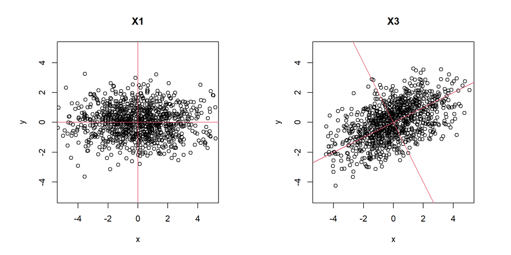

```r
par(mfrow=c(1,2),pty="s")
plot(X1, xlim=c(-5,5), ylim=c(-5,5), main="X1");
abline(0,0, col=2); abline(v=0, col=2)
plot(X3, xlim=c(-5,5), ylim=c(-5,5), main="X3");
abline(0,1/2, col=2); abline(0, -2, col=2)
```

## Outline of Theoretical Derivation of PCA

- Two key mathematical concepts are needed for PCA:
  1. Projection
  2. Spectral Decomposition
- We will also show how maximizing variance is linked to projection and spectral decomposition

# Projection

## Projection

- Projection refers to the process of mapping high-dimensional data onto a lower-dimensional subspace.
- In PCA, we seek to find the **directions** (principal components) that capture the most variance in the data.
- Mathematically, projection is achieved by multiplying the original data matrix by the matrix of **eigenvectors** (principal components) to obtain the projected data in the lower-dimensional space.

## A Fun Example

Here is a fun example to illustrate the concept of projection:

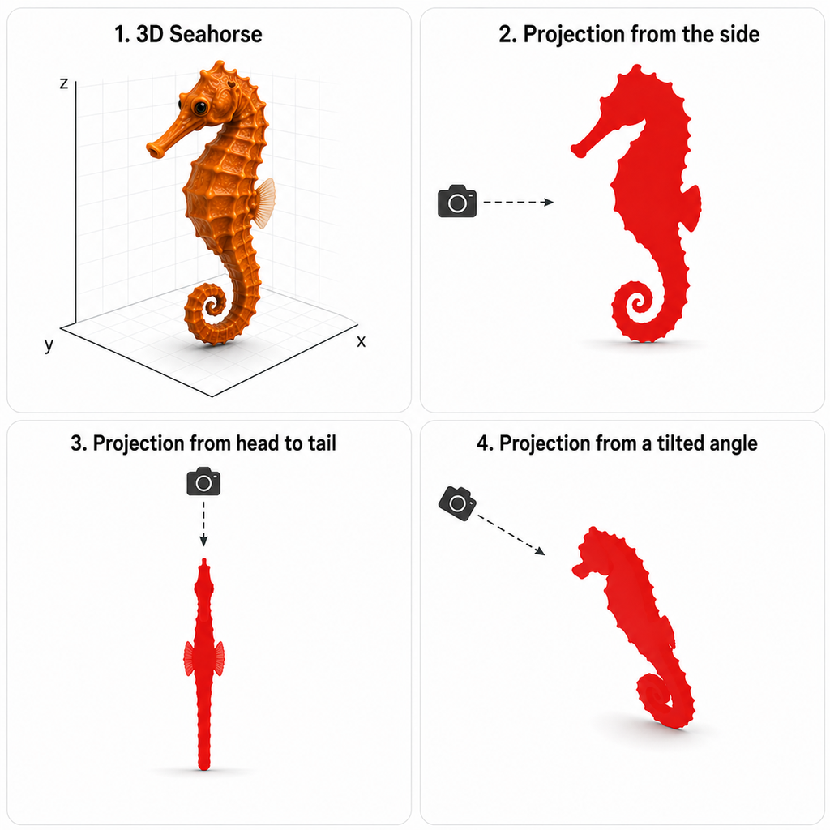

- Alternative text of the image in the previous page
1. A 3D orange seahorse shown in a coordinate grid with x, y, and z axes.
2. Side view projection of the seahorse as a red sihouette that is easy to recognize.
3. Head-to-tail projection of the seahorse as a narrow red sihouette that is hard to recognize.
4. Projection of the seahorse from a titled angle as a red sihouette that is not easy to recognize.

## Mathematical Formulation

- Let $x$ and $y$ be two vectors in $\mathbf R^k$.

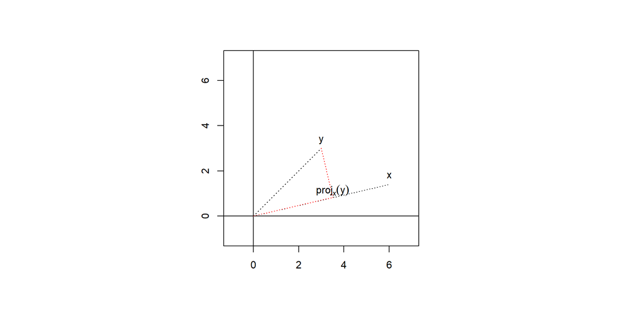

```r
# Define the vectors
y <- c(3, 3)
x <- c(6, 1.4)
# Compute the projection of v1 onto v2
proj <- (sum(y * x) / sum(x * x)) * x
# Create a plot
par(pty="s")
plot(0, 0, xlim = c(-1, 7), ylim = c(-1, 7), type = "n", xlab = " ", ylab = " ")
abline(h = 0, v = 0)
text(y[1], y[2], "y", pos = 3)
text(x[1], x[2], "x", pos = 3)
text(proj[1], proj[2]-0.2, expression(proj[x](y)), pos = 3)
segments(0, 0, y[1], y[2], lty = "dotted")
segments(0, 0, x[1], x[2], lty = "dotted")
segments(y[1], y[2], proj[1], proj[2], lty = "dotted", col = "red")
segments(0, 0, proj[1], proj[2], lty = "dotted", col = "red")
```

## Mathematical Formulation

- The direction of $proj_x(y)$ is the same as that of $x$.
- Let $\theta$ is the angle between $x$ and $y$.
  $$cos(\theta) = \frac{x^Ty}{||x|| ||y||}$$
- The length of the projection is $||y|| cos(\theta)$.
- The projection of $y$ on $x$ is
  $$||y|| cos(\theta) \frac{x}{||x||}=\frac{x^Ty}{||x||^2} x$$

# Spectral Decomposition

## Spectral Decomposition

- Spectral decomposition, also known as eigendecomposition
- It says that a symmetric matrix can be decomposed into a set of orthogonal eigenvectors and their corresponding eigenvalues.
- For a symmetric matrix $A_{p\times p}$, the spectral decomposition is given by: $A = \Gamma {\Lambda} \Gamma^T$, where
  - $\Gamma$ is an orthogonal matrix
  - $\Lambda$ is a diagonal matrix

## Eigenvectors

- $\Gamma$ is an orthogonal matrix, i.e., $\Gamma$ s.t. $\Gamma \Gamma^T= \Gamma^T \Gamma=\mathbf I_p$.
- The columns of $\Gamma$ are the eigenvectors of ${A}$. Let $\gamma_i$ denote the $i$th column, then $\Gamma=(\gamma_1, \cdots, \gamma_p)$ and each $\gamma_i$ is a $p\times 1$ vector; in other words, $\gamma_i \in \mathbb R^p$.
- $\Gamma$ is an orthogonal matrix. This implies that $\mathbf I = \Gamma\Gamma^T=(\gamma_1, \cdots, \gamma_p)(\gamma_1, \cdots, \gamma_p)^T=\sum_{i=1}^p \gamma_i \gamma_i^T$ and

$$\gamma_i^T\gamma_j=\left\{
\begin{array}{ccc}
1 & & \mbox{ if } i=j\\
0 & & \mbox{ if } i\ne j
\end{array}
\right.$$

## Eigenvalues

- ${\Lambda}$ is a diagonal matrix containing the eigenvalues of $A$:

$${\Lambda} = \begin{pmatrix}
\lambda_1 & 0 & 0 \cdots & 0\\
0 & \lambda_2 & 0\cdots & 0\\
\cdots & \cdots & \cdots & \cdots\\
0 & 0 & 0 & \lambda_p
\end{pmatrix}$$

- Without of loss of generality, we often rank the eigenvalues,
  $$\lambda_1\ge \lambda_2 \ge \cdots \ge \lambda_p$$

## Understanding Spectral Decomposition

- $\lambda_i$ is the $i$th eigenvalue and $\gamma_i$ is the corresponding eigenvector, i.e.,
  $$A\gamma_i = \lambda_i \gamma_i$$
- The spectral decomposition $A = \Gamma \Lambda \Gamma^T$ implies that
  $$\Gamma^T A \Gamma = \Lambda, \quad A=\sum_{i=1}^p \lambda_i \gamma_i \gamma_i^T$$

## Example: Covariance Matrix

- Let $\boldsymbol\Sigma_{p\times p}$ be the covariance matrix of $\mathbf X$.
- A covariance matrix is positive definite or positive semi-definite, which means
  $$\Sigma = \Gamma \Lambda \Gamma^T$$
  where $\Lambda$ is diagonal matrix with non-negative diagonal elements:
  $$\lambda_1 \ge \lambda_2 \ge \cdots \lambda_p\ge 0$$

## Example 1 of Spectral Decomposition

$\Sigma_1$, eigenvalues, and eigenvectors.

```r
Sigma1
```

```
     [,1] [,2]
[1,]    4    0
[2,]    0    1
```

```r
eigen(Sigma1)$value #\lambda's
```

```
[1] 4 1
```

```r
eigen(Sigma1)$vectors #\Gamma
```

```
     [,1] [,2]
[1,]   -1    0
[2,]    0   -1
```

## Example 2 of Spectral Decomposition

$\Sigma_3$, eigenvalues, and eigenvectors.

```r
Sigma3
```

```
         [,1]     [,2]
[1,] 3.250000 1.299038
[2,] 1.299038 1.750000
```

```r
eigen(Sigma3)$value #\lambda's
```

```
[1] 4 1
```

```r
eigen(Sigma3)$vectors #\Gamma
```

```
           [,1]       [,2]
[1,] -0.8660254  0.5000000
[2,] -0.5000000 -0.8660254
```

## An Orthogonal Matrix preserves Norm

- Recall that an orthogonal matrix $\Gamma$ satisfies the following properties: $\Gamma^T \Gamma = \mathbf I$, $\Gamma \Gamma^T = \mathbf I$.
- An orthogonal matrix preserves the norm of a vector:
  $$||\Gamma x|| = \sqrt{(\Gamma x)^T \Gamma x} = \sqrt{x^T \Gamma^T \Gamma x}= \sqrt{x^Tx}=||x||.$$
- It also preserves the distance between two vectors:
  $$||\Gamma x - \Gamma y|| = ||\Gamma (x-y)|| = ||x-y||.$$

## Orthogonal Transformation of A Data Points and A Data Matrix

- Consider a data point $x=\begin{pmatrix}a\\ b \end{pmatrix}$.
- Consider an orthogonal transformation. The new coordinates are
  $$\Gamma^T x=
  \begin{pmatrix}
  \gamma_1^T \\ \gamma_2^T
  \end{pmatrix} x =
  \begin{pmatrix}
  \gamma_1^T x \\ \gamma_2^T x
  \end{pmatrix}$$
- For a $n\times p$ data matrix $X$, the orthogonal transformation is $X\Gamma_{p\times p}$, which has $n$ rows and $p$ columns.

## An Orthogonal Matrix preserves Norm: Example

- R code:

```r
Gamma=eigen(Sigma3)$vectors
par(mfrow=c(1,2))
plot(X3, xlim=c(-5,5), ylim=c(-5,5), col=8, pch=".", main="X3");
points(X3[1,], col=2, pch=17)
points(X3[10,], col=3, pch=15)
abline(0,1/2, col=2); abline(0, -2, col=2)
plot(as.matrix(X3)%*%Gamma, xlim=c(-5,5), ylim=c(-5,5), col=8, pch=".", main="Gamma*X3");
points(as.matrix(X3[1,])%*%Gamma, col=2, pch=17)
points(as.matrix(X3[10,])%*%Gamma, col=3, pch=15)
abline(h=0, v=0, col=2)
```

## An Orthogonal Matrix preserves Norm: Example

[figure not shown]

## Alt text:

Two side-by-side scatterplots comparing a dataset before and after an orthogonal transformation.

- Left panel ($X^3$): A cloud of points centered near the origin, with two highlighted points (one in red triangle, one in green square). Two diagonal reference lines with slopes 1/2 and −2 indicate principal directions.
- Right panel ($X^3\Gamma$): The same points after rotation by an orthogonal matrix. The overall shape and distances between points are unchanged, but the data are reoriented so that the principal directions align with the horizontal and vertical axes. The same two highlighted points appear in new positions consistent with the rotation.

The figure illustrates that an orthogonal transformation preserves distances and norms while rotating the coordinate system.

# Example

## Example: Rotate $X_3$

- Recall that each row of $X_3$ was generated from a bivariate normal distribution with covariance matrix $\Sigma_3$, where
  $$\Sigma_3=
  \begin{pmatrix} 3.25 & 1.299038 \\
  1.299038 & 1.75
  \end{pmatrix}= \Gamma \Lambda \Gamma^T$$

The last step is due to spectral decomposition.

- If $x\sim \mathbf N(\mathbf 0, \Sigma_3)$, how about $\Gamma^T x$?
- We have learned how to find the distribution of linear transformations of a random vector.
- If $x\sim \mathbf N(\mathbf 0, \Sigma_3)$, then $\Gamma^T x$ is also normally distributed with mean $\Gamma \mathbf 0 = \mathbf 0$ and covariance matrix
  $$\Gamma^T \Sigma_3 \Gamma
  = \Gamma^T \Gamma \Lambda \Gamma^T \Gamma^T = \Lambda.$$
- For a random sample $X_3$ of size $n$ from $\mathbf N(\mathbf 0, \Sigma_3)$, the orthogonal transformation $X_3 \Gamma$ behaves like a random sample from $\mathbf N(\mathbf 0, \Lambda)$.

We have calculated that $\lambda_1=4, \lambda_2=1$.

$$\Lambda =\begin{pmatrix}
4 & 0 \\
0 & 1
\end{pmatrix}$$

- The eigenvectors

$$\Gamma =
\begin{pmatrix}
-0.8660254 & 0.5000000 \\
-0.5000000 & -0.8660254
\end{pmatrix},
\gamma_1 =
\begin{pmatrix}
-0.8660254 \\
-0.5000000
\end{pmatrix},
\gamma_2 =
\begin{pmatrix}
0.5000000 \\
-0.8660254
\end{pmatrix}$$

## $X_3$ and $X_3 \Gamma$.

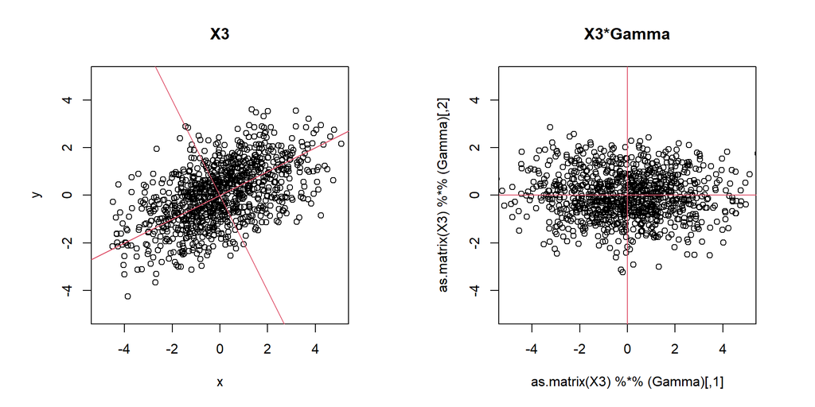

```r
Gamma=eigen(Sigma3)$vectors
par(mfrow=c(1,2),pty="s")
plot(X3, xlim=c(-5,5), ylim=c(-5,5), main="X3");
abline(0,1/2, col=2); abline(0, -2, col=2)
plot(as.matrix(X3)%*%(Gamma), xlim=c(-5,5), ylim=c(-5,5), main="X3*Gamma");
abline(h=0, v=0, col=2)
```

## In Practice

We don’t know the covariance matrix $\Sigma$ of the data, so we need to estimate it by the sample covariance matrix $S$.

Example, we first compute $S_3$ as the sample covariance matrix of $X_3$, then we perform spectral decomposition on $S_3$ to get the eigenvalues and eigenvectors.

```r
S3=cov(X3)
S3
```

```
         x        y
x 3.241303 1.242847
y 1.242847 1.632435
```

```r
eigen(S3)$value #\lambda's
```

```
[1] 3.9173363 0.9564019
```

```r
eigen(S3)$vectors #\Gamma
```

```
           [,1]       [,2]
[1,] -0.8784546  0.4778257
[2,] -0.4778257 -0.8784546
```

## $X_3$ vs Rotated Data based on $S_3$

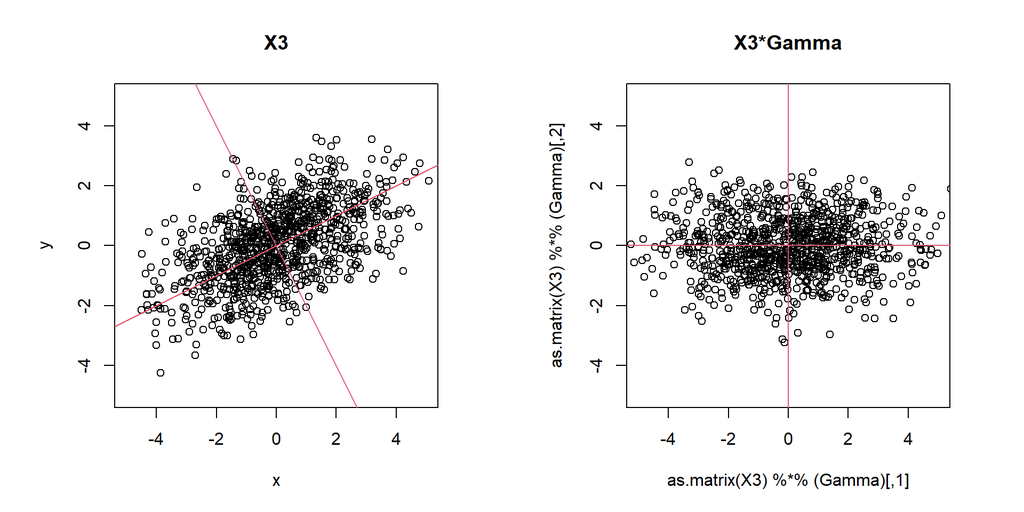

```r
Gamma=eigen(S3)$vectors
par(mfrow=c(1,2),pty="s")
plot(X3, xlim=c(-5,5), ylim=c(-5,5), main="X3");
abline(0,1/2, col=2); abline(0, -2, col=2)
plot(as.matrix(X3)%*%(Gamma), xlim=c(-5,5), ylim=c(-5,5), main="X3*Gamma");
abline(h=0, v=0, col=2)
```

## What Does Projection Do?

- Let $\gamma_1$ and $\gamma_2$ be the two columns of $\Gamma$.
- Focus on $X_3 \gamma_1$: how many values in this vector? What are they?
- The first element is the projection of the first row of $X_3$ onto $\gamma_1$.
- The second element is the projection of the second row of $X_3$ onto $\gamma_1$.
- In general, the $i$th element of $X_3 \gamma_1$ is the projection of the $i$th row of $X_3$ onto $\gamma_1$.

# Understand 1st PC

## Obtain the first PC Direction

- $\gamma_1$ is a vector
- Each entry of $\gamma_1$ corresponds to one feature
- Those entries are the loadings

```r
S3=cov(X3)
gamma1=eigen(S3)$vectors[,1]
gamma1
```

```
[1] -0.8784546 -0.4778257
```

- The two values, one for each feature, are the weights/loadings that will be used to obtain the first PC scores.

## Project An Observation (vector) to 1st PC to get the PC score

- Let $X$ be an observation, which is a vector in $\mathbb R^p$
- By the definition of projection, the projection of $X$ to $\gamma_1$ is
  $$\frac{\gamma_1^T X}{||\gamma_1||^2}\gamma_1=(\gamma_1 ^T X) \gamma_1$$
- Along the direction of $\gamma_1$, what matters is $\gamma_1^T X$, which is called the PC score of the observation.

## Project An Observation to 1st PC

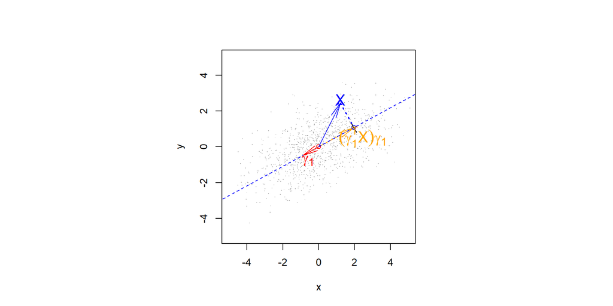

```r
par(mfrow=c(1,1),pty="s")
obs=unlist(X3[1,])
proj=c(matrix(gamma1,1,2)%*%matrix(obs,2,1)) *gamma1
plot(X3, xlim=c(-5,5), ylim=c(-5,5), col=8, pch=".");
points(x=0,y=0, col="red")
points(x=obs[1], y=obs[2], col="blue")
points(x=proj[1], y=proj[2], col="blue")
arrows(x0=0, y0=0,x1=obs[1], y1=obs[2], col="blue", lwd=1, angle=10)
arrows(x0=0, y0=0,x1=proj[1], y1=proj[2], col="orange", lwd=1, angle=10)
segments(0,0, 10*gamma1[1], 10*gamma1[2], col="blue", lty=2)
arrows(x0=0, y0=0,x1=gamma1[1], y1=gamma1[2], col="red", lwd=1, angle=10)
segments(0,0, -10*gamma1[1], -10*gamma1[2], col="blue", lty=2)
segments(obs[1], obs[2], proj[1], proj[2], lty = "dotted", col = "blue", lwd=2)
text(x=proj[1],y=proj[2], labels="|", col="black", srt=30, cex=1)
text(x=gamma1[1]+0.3, y=gamma1[2]-0.3, labels=expression(gamma[1]), col="red", cex=1.5)
text(x=obs[1], y=obs[2]+0.2, labels="X", col="blue", cex=1.5)
text(x=proj[1]+0.5, y=proj[2]-0.5, labels=expression( (gamma[1]^T * X)*gamma[1]), col="orange", cex=1.5)
```

## Project All Observations to 1st PC

```r
par(mfrow=c(1,1),pty="s")
plot(X3, xlim=c(-5,5), ylim=c(-5,5), col=8, pch=".");
#arrows(x0=0, y0=0,x1=-6*gamma1[1], y1=-6*gamma1[2], col=2, lwd=2, angle=10)
#arrows(x0=0, y0=0,x1=6*gamma1[1], y1=6*gamma1[2], col=2, lwd=2, angle=10)
abline(0,1/sqrt(3), col="red"); abline(0, -sqrt(3), col="red")
points(x=0,y=0, col="red")
for(i in 1:1000){
  proj=c(matrix(gamma1,1,2)%*% matrix(unlist(X3[i,]),2,1)) *gamma1
  #points(x=proj[1],y=proj[2], col=2, pch="|")
  text(x=proj[1],y=proj[2], labels="|", col="blue", srt=30, cex=0.5)
}
```

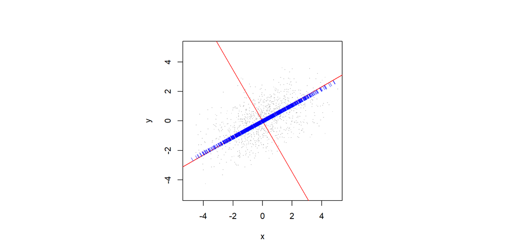

# Understand 2nd PC

## Obtain the second PC direction

- $\gamma_2$ is the second column of $\Gamma$.

```r
gamma2=eigen(S3)$vectors[,2]
gamma2
```

```
[1]  0.4778257 -0.8784546
```

- The two values, one for each feature, are the weights/loadings that will be used to obtain the second PC scores.

## Project An Observation (vector) to 2nd PC to get the PC score

- Let $X$ be an observation, which is a vector in $\mathbb R^p$
- By the definition of projection, the projection of $X$ to $\gamma_2$ is
  $$\frac{\gamma_2^T X}{||\gamma_2||^2}\gamma_2=(\gamma_2 ^T X) \gamma_2$$
- Along the direction of $\gamma_2$, what matters is $\gamma_2^T X$, which is called the PC score of the observation.

## Project An Observation to 2nd PC

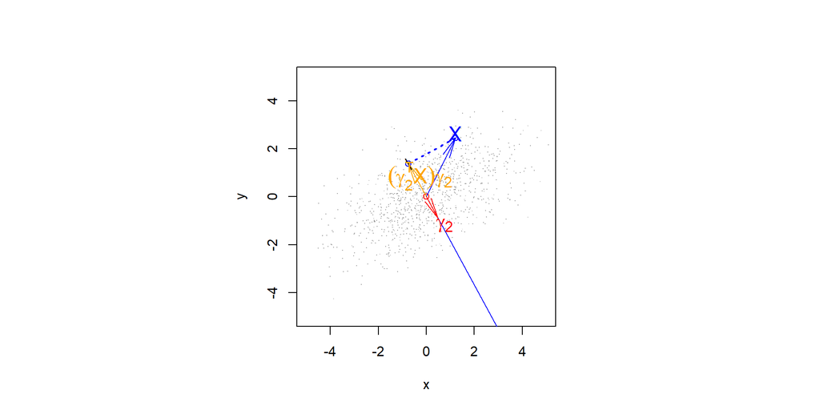

```r
par(mfrow=c(1,1),pty="s")
obs=unlist(X3[1,])
proj=c(matrix(gamma2,1,2)%*%matrix(obs,2,1)) *gamma2
plot(X3, xlim=c(-5,5), ylim=c(-5,5), col=8, pch=".");
points(x=0,y=0, col="red")
points(x=obs[1], y=obs[2], col="blue")
points(x=proj[1], y=proj[2], col="blue")
arrows(x0=0, y0=0,x1=obs[1], y1=obs[2], col="blue", lwd=1, angle=10)
arrows(x0=0, y0=0,x1=proj[1], y1=proj[2], col="orange", lwd=1, angle=10)
segments(0,0, 10*gamma2[1], 10*gamma2[2], col="blue", lty=1)
arrows(x0=0, y0=0,x1=gamma2[1], y1=gamma2[2], col="red", lwd=1, angle=10)
segments(obs[1], obs[2], proj[1], proj[2], lty = "dotted", col = "blue", lwd=2)
text(x=proj[1],y=proj[2], labels="|", col="black", srt=30, cex=1)
text(x=gamma2[1]+0.3, y=gamma2[2]-0.3, labels=expression(gamma[2]), col="red", cex=1.5)
text(x=obs[1], y=obs[2]+0.2, labels="X", col="blue", cex=1.5)
text(x=proj[1]+0.5, y=proj[2]-0.5, labels=expression( (gamma[2]^T * X)*gamma[2]), col="orange", cex=1.5)
```

## Project All Observations to 2nd PC

```r
par(mfrow=c(1,1),pty="s")
plot(X3, xlim=c(-5,5), ylim=c(-5,5), col=8, pch=".");
#arrows(x0=0, y0=0,x1=-6*gamma2[1], y1=-6*gamma2[2], col=2, lwd=2, angle=10)
#arrows(x0=0, y0=0,x1=6*gamma2[1], y1=6*gamma2[2], col=2, lwd=2, angle=10)
abline(0,1/sqrt(3), col="red"); abline(0, -sqrt(3), col="red")
points(x=0,y=0, col="red")
for(i in 1:1000){
  proj=c(matrix(gamma2,1,2)%*% matrix(unlist(X3[i,]),2,1)) *gamma2
  #points(x=proj[1],y=proj[2], col=2, pch="|")
  text(x=proj[1],y=proj[2], labels="|", col="blue", srt=120, cex=0.5)
}
```

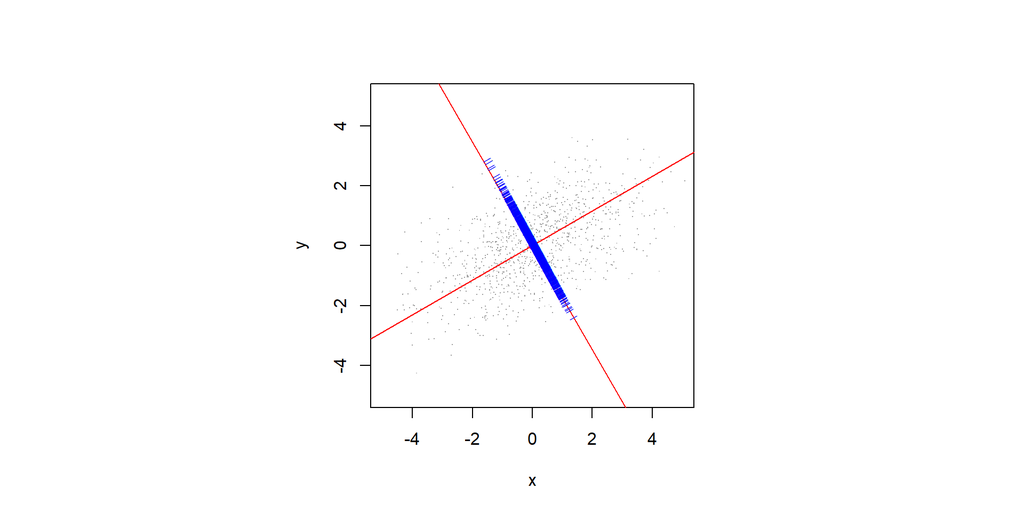

## First vs Second PC

Let’s compare their variance based on simulated data $X_3$. Recall that the data matrix $X_3$ has 1000 rows and 2 columns, and $\Gamma$ is a 2-by-2 matrix with the first column $\gamma_1$ and the second column $\gamma_2$.

- First component $X_3 \gamma_1$: 1000-by-1 vector of the first PC scores, where the $i$th element is the projection of the $i$th row of $X_3$ onto $\gamma_1$;
- second component $X_3 \gamma_2$: 1000-by-1 vector of the second PC scores, where the $i$th element is the projection of the $i$th row of $X_3$ onto $\gamma_2$.

# Maximiation of Variance

## Empirical Results

- variance of the first PC scores

```r
var(as.matrix(X3)%*%gamma1)
```

```
         [,1]
[1,] 3.917336
```

- variance of the second PC scores

```r
var(as.matrix(X3)%*%gamma2)
```

```
          [,1]
[1,] 0.9564019
```

- Need to show mathematical derivation

## Identify the 1st PC

- Let $Y_1=a^T \mathbf X$ denote the linear combination reaches the maximum variance subject to $||a||=1$:
  $$a=\underset{a^T a=1} {\mbox{arg max }} a^T \boldsymbol \Sigma a$$
- The variance of $Y_1$ in terms of $\Gamma$ and $\Lambda$
  $$\begin{aligned}
  Var(Y_1) &= a^T\Sigma a= a^T \Gamma \Lambda \Gamma^T a = a^T (\sum_{i=1}^p \lambda_i \gamma_i\gamma_i^T) a \\
  &= \sum_{i=1}^p \lambda_i a^T \gamma_i \gamma_i^T a = \sum_{i=1}^p \lambda_i z_i^2
  \end{aligned},$$
  where $z_i=a^T\gamma_i=\gamma_i^T a=<a, \gamma_i>=<\gamma_i, a>$.

## Identify the 1st PC

- Also,
  $$\begin{aligned}
  \sum_{i=1}^p z_i^2 &=\sum_{i=1}^p a^T \gamma_i \gamma_i^T a=a^T \left(\sum_{i=1}^p \gamma_i \gamma_i^T\right) a\\
  &=a^T \Gamma \Gamma^T a\overset{1}=a^T\mathbf I a \\
  &= a^Ta \overset{2}=1
  \end{aligned}$$
  - step 1: this is because $\Gamma$ is an orthogonal matrix, which means $\Gamma\Gamma^T=\Gamma^T\Gamma=\mathbf I$.
  - step 2: this is due to the constraint that $a^Ta=1$.

## Identify the 1st PC

So far we have the following results

- $Var(a^TX)=\sum_{i=1}^p \lambda_i z_i^2$, where
  $$\lambda_1\ge \cdots \lambda_p\ge0$$
- $\sum_{i=1}^p z_i^2=1.$
- These facts can be used to maximize
  $$Var(Y_1) = Var(a^T X).$$
- Thus,
  $$\begin{aligned}
  Var(a^T \mathbf X)&=\sum_{i=1}^p \lambda_i z_i^2 \overset{?}\le \sum_{i=1}^p \lambda_1 z_i^2
  \\
  &=\lambda_1 \sum_{i=1}^p z_i^2\\
  &=\lambda_1
  \end{aligned}$$
  Thus, the maximum $Var(a^TX)=\lambda_1$ s.b.t. $||a||=1$.
- These facts can be used to maximize $Var(Y_1) = Var(a^T X)$.

## Identify the 1st PC

- But how to find $a$?
- Which $z=(z_1, \cdots, z_p)^T$ makes the $=$ hold?
- This happens when $z_1=1, z_2=0, \cdots z_p=0$
- Recall that $z_i=a^T \gamma_i$
- Thus, the following $a$ satisfies all required conditions
  $$a=\gamma_1$$

## Conclusion for the first PC

- Thus, we can conclude that among all the linear combinations of $\mathbf X$ with the norm of the linear coefficients being 1,
- the one with the largest variance is $\gamma_1^T \mathbf X$, and
- the maximum variance is $\lambda_1$.
- For notional clarity, let’s denote the first PC by $Y_1=\gamma_1^T \mathbf X$

## Maximization: 2nd PC

- Let $Y_2=a^T \mathbf X$ denote the second PC. It is defined as a linear combination of $\mathbf X$ such that
  1. It is uncorrelated to $Y_1=\gamma_1^T \mathbf X$, i.e.,
     $$0=cov(a^T \mathbf X, \gamma_1^T \mathbf X)=a^T \boldsymbol \Sigma \gamma_1$$
  2. The linear coefficients $a$ has norm 1, i.e.,
     $$1=||a||=||a||^2=a^Ta$$
  3. It reaches the maximum variance among all the linear combinations satisfying the first two conditions
- Mathematically, we are looking for $a$ s.t.
  $$a=\underset{a^T a=1, a^T\boldsymbol \Sigma\gamma_1=0} {\mbox{arg max }} a^T \boldsymbol \Sigma a$$
- This means that we woud like to solve the following optimization problem:
  $$max(a^T\boldsymbol \Sigma a) \mbox { s.b.t. } a^Ta=1 \mbox{ and } a^T\boldsymbol\Sigma \gamma_1=0$$
- Rewrite $Var(a^T \mathbf X)$:

$$\begin{aligned}
Var(a^T \mathbf X) &= a^T \boldsymbol \Sigma a=a^T \left(\sum_{i=1}^p \lambda_i \gamma_i \gamma_i^T\right) a\\
&=\sum_{i=1}^p \lambda_i a^T \gamma_i \gamma_i^T a\\
& \overset{\mbox{Let } z_i=a^T\gamma_i}=\sum_{i=1}^p \lambda_i z_i^2
\end{aligned}$$

## Identify the 2nd PC

- The first constraint of $a$ is $a^T\boldsymbol\Sigma \gamma_1=0$.
- Recall that $\gamma_1$ is an eigenvector of $\boldsymbol \Sigma$ with the corresponding eigenvalue $\lambda_1$, we have
  $$\boldsymbol \Sigma \gamma_1=\lambda_1\gamma_1$$
  Thus the constraint $a^T\boldsymbol\Sigma \gamma_1=0$ implies that $a^T\gamma_1=0$, which further implies that $z_1=0$. As a result, we have

  $$Var(a^T \mathbf X)=\sum_{i=2}^p \lambda_i z_i^2$$

## Identify the 2nd PC

- The second constraint of $a$ is $a^T a=1$.
- With this constraint, we have

  $$\begin{aligned}
  1&=a^Ta = a^T\mathbf I a= a^T\Gamma \Gamma^T a\\
  &= (z_1, \cdots, z_p)(z_1, \cdots, z_p)^T\\
  &=\sum_{i=1}^p z_i^2=\sum_{i=2}^p z_i^2
  \end{aligned}$$

## Identify the 2nd PC

- From the previous slide
  $$\begin{aligned}
  Var(a^T \mathbf X)
  &= \sum_{i=2}^p \lambda_i z_i^2\\
  &\le \sum_{i=2}^p \lambda_2 z_i^2\\
  &= \lambda_2
  \end{aligned}$$
- It can also be verified that $a=\gamma_2$ leads to this maximum.
- Therefore, the second PC is $Y_2 = \gamma_2^T \mathbf X$.

## Identify the 3rd PC and Beyond

- For the rest of the PCs, i.e, 3rd, …, $p$th, we can use the same idea to identify them one by one.

# Variance Exaplained

## Dimensionality Reduction Using PCA

- PCA aims to reduce the dimensionality of a dataset while preserving as much variance as possible.
- Dimensionality reduction using PCA can
  - ease visualization and analysis
  - help identify underlying patterns or structure in the data.
  - improve the performance of machine learning algorithms by reducing noise and collinearity.
- PCA is most effective when the majority of the variance can be captured by a small number of principal components.

## Total Variance

- There are at least two justifications to use $\sum_{i=1}^p \lambda_i$ as the total variance:
  1. One way to quantify the total variance in $\mathbf X$ is the trace of the covariance matrix $\boldsymbol \Sigma$
  - Recall that $tr(\boldsymbol \Sigma)= \sum_{i=1}^n \lambda_i$
  2. The variance of $i$th PC is $Var(Y_i)=Var(\gamma_i^T\mathbf X)=\lambda_i$. Thus, the total variance of PCs is
     $$\sum_{i=1}^p Var(Y_i)=\sum_{i=1}^p \lambda_i$$

## Variance Explained

- The proportion of the variance explained by $i$th PC explains is
  $$\lambda_i/\sum_{i=1}^p \lambda_i$$
- Cumulative Explained Variance is the proportion of the total variance explained by the first $k$ PCs is
  $$\frac{\sum_{i=1}^k \lambda_i}{\sum_{i=1}^p \lambda_i}$$

## Variance Explained: Example

```r
lambda=eigen(S3)$values
# Prop of Variance explained by 1st PC
lambda[1]/sum(lambda)
```

```
[1] 0.8037642
```

```r
# Prop of Cumulative Variance explained by two PCs
sum(lambda[1:2])/sum(lambda)
```

```
[1] 1
```

- In this example, 1st PC explains about $80\%$ of variance, 2nd PC explains about $20\%$ of variance.